# 意大利新冠肺炎疫情预测及理性评估

2020年6月12日

## 1引言

- 1.1 背景及研究内容
- 1.2 文献综述

## 1.1 背景及研究内容

2019年12月，我国湖北省武汉市陆续出现多起不明原因的病毒性肺炎，一种新发现的冠状病毒随即被确认为导致武汉不明原因肺炎病例的病原体。2020年1月12日，世界卫生组织将该病毒命名为“2019新型冠状病毒(2019-nCoV)”，同年2月11日，国际病毒分类委员会又将其正式更名为严重急性呼吸综合征冠状病毒2(SARS-Cov-2)，世界卫生组织于同日该病毒导致的疾病正式命名为2019新型冠状病毒疾病(COVID-19)，国家卫健委随后将新型冠状病毒肺炎的英文缩写标准化为COVID-19。COVID-19传染性极强，迅速从武汉蔓延至全国各地，并在境外多个国家和地区传播，波及全球200多个国家。

根据最新数据统计，全球新冠肺炎累计确诊病例数突破731万例。目前，全球有8个国家累计确诊数超过20万，其中，美国累计确诊病例已经突破204万例，意大利、巴西等7个国家的累计确诊病例最新突破20万。此次新冠肺炎疫情给全世界带来了前所未有的挑战，其后续影响难以估量。意大利作为世界旅游业较发达的国家之一，也不可避免地受到了严重的影响。这种影响不仅发生于意大利与其他国家之间，更发生于意大利国内的方方面面。

因此，本文分别利用指数平滑以及ARIMA模型对意大利新冠肺炎情况进行了预测分析，并利用灰色系统分析方法具体定量分析新冠肺炎对2020年意大利旅游收入产生的损失。

## 1.2 文献综述

[1]林硕蕾.灰色系统在经济上的应用-定量分析SARS对旅游外汇收入的影响

文献利用灰色系统理论建立GM（1,1）模型，由1997-2002年旅游外汇收入的平均值预测2003年旅游外汇收入平均值；并通过历史数据计算每个月的指标值与全年总值的关系，得出每个月旅游外汇收入所占全年旅游收入的权重，从而预测出正常情况下2003年每个月外汇旅游收入的指标值；最后将其与2003年每月外汇旅游收入的真实值进行比较，定量分析SARS对旅游外汇收入的影响。

[2]王旭艳,喻勇,胡樱,宇传华.基于指数平滑模型的湖北省新冠肺炎疫情预测分析[J].公共卫生与预防医学,2020,31(01):1-4.

王旭艳等人利用1月23日到3月25日湖北省疫情数据，采用平滑指数模型对湖北省新冠肺炎疫情变化趋势进行分析和预测。结果表明，采用指数平滑模型获得的拟合值与实际值的趋势基本吻合，模型拟合效果较好，预测结果表明在4月2日现存确诊病例数将减少至1000例以内，且主要为重症和危重症病例。

[3]严婧，杨北方.指数平滑法与ARIMA模型在湖北省丙型病毒性肝炎发病预测中的应用

研究对湖北省丙肝疫情资料进行整理，将2004年1月－2014年12月丙肝发病数据作为建模部分，2015年1－12月发病数据作为模型验证分部，对丙肝不同年份发病率进行趋势卡方检验，建立 ARIMA模型和指数平滑法，并进行模型的参数估计、拟合检验、计算和预测、检验与评价。将预测值与实际值 进行比较，计算相对误差绝对值，相对误差绝对值越小说明预测越准确，然后进行型预测效果比较。

## 2数据来源及描述统计

- 2.1 数据来源
- 2.2 意大利疫情基本描述
- 2.3 疫情下的意大利旅游经济

## 2.1 数据说明

疫情数据来源于世界卫生组织官网(https://www.who.int/)，选取意大利3月1日-6月7日的数据，具体包括累计确诊人数、新增确诊人数、累计治愈、新增治愈人数、累计死亡人数以及新增死亡人数。根据每日疫情数据，可以依据累计确诊人数、累计死亡人数以及累计治愈人数求得现存确诊人数，以及移除人数，其中现存确诊人数=累计确诊人数-累计死亡人数-累计治愈人数，移除人数=累计死亡人数+累计治愈人数。

有关意大利旅游收入的数据来源于(https://zh.tradingeconomics.com/)。为了避免2008年金融危机对本次分析产生影响，我们选取2009年-2020年的数据。

## 2.2 意大利疫情基本描述

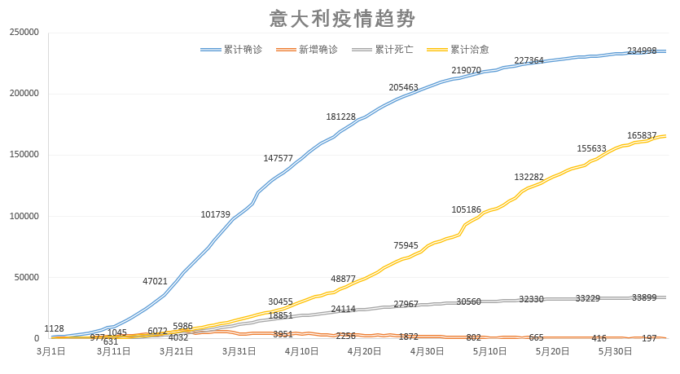

截至6月7日，意大利累计确诊人数达23万之多，累计病例数从3月初开始迅速增加，到5月份左右减缓，而后趋于稳定，尤其在近日以来，新增确诊病例数在200左右波动，并且在不断减少，说明意大利疫情得到了较好的控制。

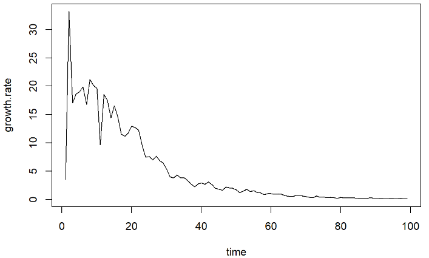

## 2.3 疫情下的意大利旅游经济

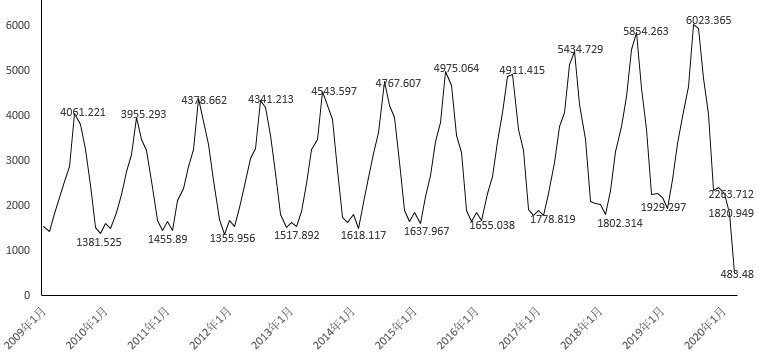

意大利2009-2020年的旅游收入走势图显示，旅游收入逐年上升，并呈规律性的周期变化，在每年7月份左右旅游收入最高，1月份左右最低。由于COVID-19的影响，意大利2020年的旅游收入在一月份下滑后并没有回升，甚至在3月份降到了483.48百万欧元，降到了近十年的最低点，可见COVID-19疫情对意大利经济有着不容忽视的影响。